# Modelos de Box y Jenkins

### 5.5.2 Normalidad de Residuos

Se verifica en los residuos QQ-normal y el histograma.

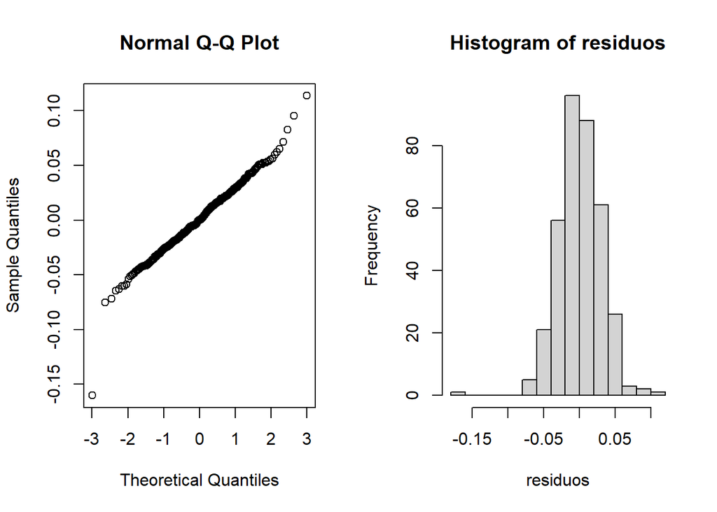

```r
par(mfrow=c(1,2))
qqnorm(residuos)
hist(residuos)
```

Se puede observar la existencia de datos atípicos, efectivamente si se ven los residuos a más detalle existe un valor atípico en diciembre del 2016, el cual se mencionó en el estudio de tendencia un decaimiento bastante fuerte a lo usual de la serie temporal. Este valor atípico puede que este produciendo algún tipo de sesgo en el estudio de normalidad.

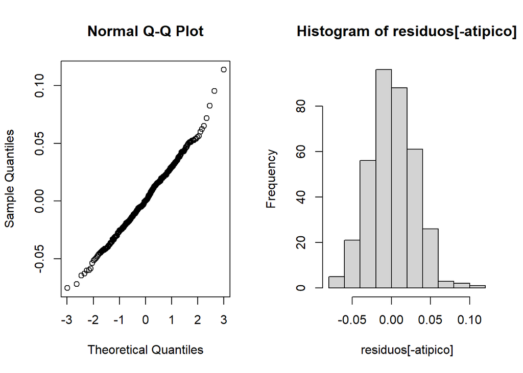

```r
atipico<-which.min(residuos)
par(mfrow=c(1,2))
qqnorm(residuos[-atipico])
hist(residuos[-atipico])
```

Visualmente al quitar este valor atípico se puede observar que posiblemente exista normalidad en los residuos. Para poder determinar el mismo se realizarán las dócimas de normalidad con este valor atípico y sin él.

Se realizará las pruebas de normalidad.

- **Dócima de Jarque-Bera**

La dócima de Jarque-Bera tiene la siguiente hipótesis nula

$$H_0: \text{ Los residuos son normales}$$

```r
normtest::jb.norm.test(residuos)
```

```
##
##  Jarque-Bera test for normality
##
## data:  residuos
## JB = 76.727, p-value < 2.2e-16
```

Se rechaza la hipótesis nula donde se concluye que los residuos no cumplen normalidad como se pudo observar en el gráfico.

```r
normtest::jb.norm.test(residuos[-atipico])
```

```
##
##  Jarque-Bera test for normality
##
## data:  residuos[-atipico]
## JB = 4.8267, p-value = 0.0805
```

Sin contar con este dato se puede observar que no se rechaza la hipótesis nula, teniendo así normalidad en los residuos.

- **Dócima de Shapiro-Wilk**

La dócima de Shapiro-Wilk tiene la siguiente hipótesis nula

$$H_0: \text{La distribución es normal}$$

```r
shapiro.test(residuos)
```

```
##
##  Shapiro-Wilk normality test
##
## data:  residuos
## W = 0.98086, p-value = 0.0001029
```

Se rechaza la hipótesis nula donde se concluye que los residuos no cumplen normalidad.

```r
shapiro.test(residuos[-atipico])
```

```
##
##  Shapiro-Wilk normality test
##
## data:  residuos[-atipico]
## W = 0.99465, p-value = 0.2451
```

No se rechaza la hipótesis nula donde se concluye que los residuos cumplen normalidad.

**Conclusión:** Se puede evidenciar que no existe normalidad en los residuos teniendo en cuenta el valor atípico sucitado en diciembre del 2016. No tomando en cuenta este valor se puede decir que los residuos son normales

### 5.5.3 Homocedasticidad de Residuos

Se hará primero un análisis gráfico.

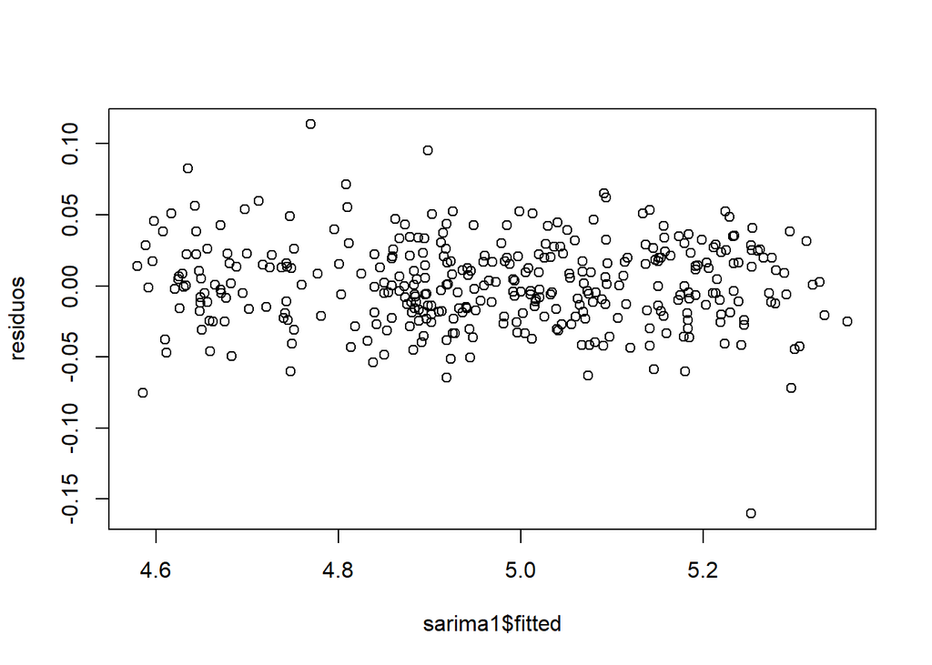

```r
plot(sarima1$fitted,residuos)
```

Se puede evidenciar que existe un valor atípico el cual corresponde a diciembre del 2016, pero según el gráfico existiria homocedasticidad, sin contar con ese valor atípico.

**Dócima de White**

La hipótesis a contrastar es:

$$H_0: \text{ Residuos son homocedasticos}$$

```r
white.test(residuos)
```

```
##
##  White Neural Network Test
##
## data:  residuos
## X-squared = 2.2507, df = 2, p-value = 0.3245
```

Se concluye que no se rechaza la hipótesis nula, teniendo así evidencia estadística para decir que los residuos son homocedásticos.

**Dócima de Breush-Pagan**

La hipótesis a contrastar es:

$$H_0: \text{ Residuos son homocedasticos}$$

```r
residuos_fit<-lm(residuos[-1] ~ residuos[-length(residuos)])
bptest(residuos_fit)
```

```
##
##  studentized Breusch-Pagan test
##
## data:  residuos_fit
## BP = 0.0039868, df = 1, p-value = 0.9497
```

No se rechaza la hipótesis nula.

**Conclusión:** Existe evidencia estadística para decir que los residuos son homocedasticos, no presentando así heterocedasticidad.

## 5.6 Conclusión ajuste del modelo

Se puede concluir entonces que el modelo elegido $SARIMA(0,1,1)(1,0,1)_{12}$ tiene el menor AIC teniendo residuos independientes y homocedásticos, en cuanto a la normalidad sin contar con el valor atípico del 2016 se puede asumir este supuesto.

# 6 Gráfico serie original y el ajustado

Primero gráficamos la serie del ICAP aplicado a logaritmo y el ajuste del modelo $SARIMA(0,1,1)(1,0,1)_{12}$

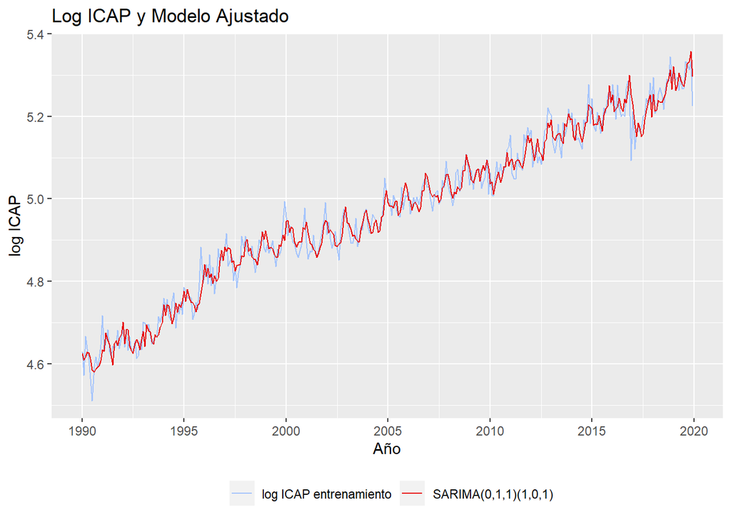

```r
autoplot(log_serie_ent,series="log ICAP entrenamiento")+
  autolayer(sarima1$fitted,series = "SARIMA(0,1,1)(1,0,1)")+
  ggtitle("Log ICAP y Modelo Ajustado")+
  xlab("Año")+ylab("log ICAP")+
  scale_color_manual(values=c("#A4C4FC","#E80808"))+
  theme(legend.position = "bottom",legend.title = element_blank() )
```

Ahora gráficamos la serie original del ICAP y el inverso del logaritmo (exponencial) al modelo ajustado.

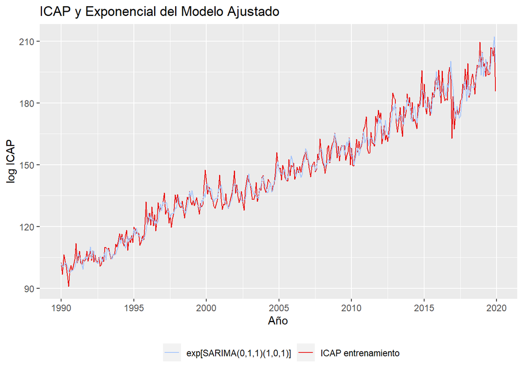

```r
autoplot(serie_ent,series="ICAP entrenamiento")+
  autolayer(exp(sarima1$fitted),series = "exp[SARIMA(0,1,1)(1,0,1)]")+
  ggtitle("ICAP y Exponencial del Modelo Ajustado")+
  xlab("Año")+ylab("log ICAP")+
  scale_color_manual(values=c("#A4C4FC","#E80808"))+
  theme(legend.position = "bottom",legend.title = element_blank() )
```

# 7 Predicción

Se realizará la predicción para el conjunto test del ICAP.

```r
prediccion<-forecast(sarima1,19)
prediccion
```

```
##          Point Forecast    Lo 80    Hi 80    Lo 95    Hi 95
## Jan 2020       5.316774 5.278336 5.355212 5.257988 5.375560
## Feb 2020       5.267360 5.227197 5.307523 5.205936 5.328784
## Mar 2020       5.272496 5.230679 5.314313 5.208543 5.336449
## Apr 2020       5.282364 5.238956 5.325771 5.215978 5.348750
## May 2020       5.287944 5.243002 5.332886 5.219211 5.356677
## Jun 2020       5.271778 5.225352 5.318204 5.200776 5.342780
## Jul 2020       5.269846 5.221982 5.317710 5.196645 5.343047
## Aug 2020       5.302260 5.253001 5.351520 5.226924 5.377596
## Sep 2020       5.316745 5.266128 5.367362 5.239333 5.394157
## Oct 2020       5.315744 5.263805 5.367683 5.236310 5.395178
## Nov 2020       5.342889 5.289661 5.396117 5.261483 5.424294
## Dec 2020       5.278540 5.224054 5.333027 5.195210 5.361870
## Jan 2021       5.330827 5.272537 5.389117 5.241680 5.419974
## Feb 2021       5.283934 5.223894 5.343974 5.192111 5.375757
## Mar 2021       5.288808 5.227068 5.350549 5.194384 5.383232
## Apr 2021       5.298173 5.234777 5.361568 5.201218 5.395128
## May 2021       5.303468 5.238460 5.368476 5.204047 5.402889
## Jun 2021       5.288127 5.221545 5.354709 5.186299 5.389955
## Jul 2021       5.286294 5.218174 5.354413 5.182114 5.390473
```

Primero gráficamos la serie del ICAP tanto de entrenamiento como de test aplicado a logaritmo y el ajuste del modelo $SARIMA(0,1,1)(1,0,1)_{12}$ más su predicción.

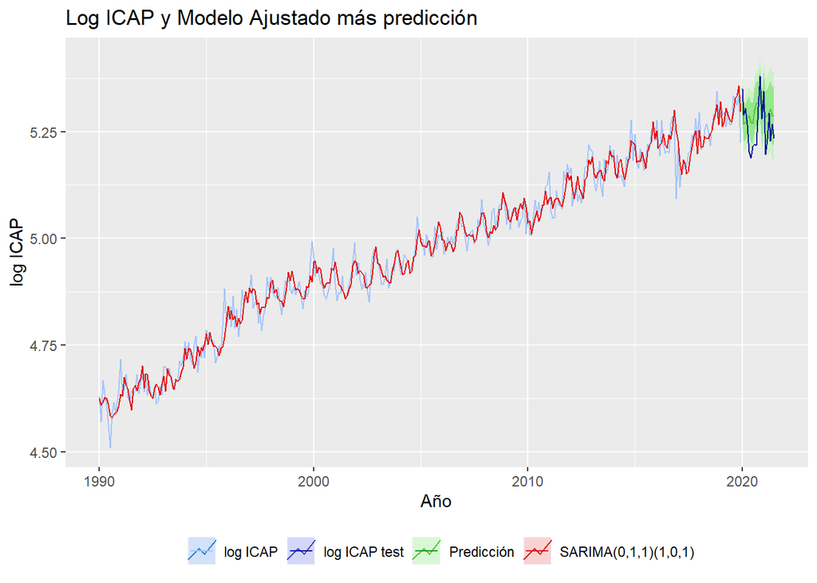

```r
autoplot(log_serie_ent,series="log ICAP")+
  autolayer(sarima1$fitted,series = "SARIMA(0,1,1)(1,0,1)")+
  autolayer(prediccion,series = "Predicción")+
  autolayer(log(serie_test),series = "log ICAP test")+
  ggtitle("Log ICAP y Modelo Ajustado más predicción")+
  xlab("Año")+ylab("log ICAP")+
  scale_color_manual(values=c("#A4C4FC","#0D139B","#189B0D","#E80808"))+
  theme(legend.position = "bottom",legend.title = element_blank() )
```

Ahora gráficamos la serie original del ICAP tanto de entrenamiento como de test y el inverso del logaritmo (exponencial) al modelo ajustado más su predicción.

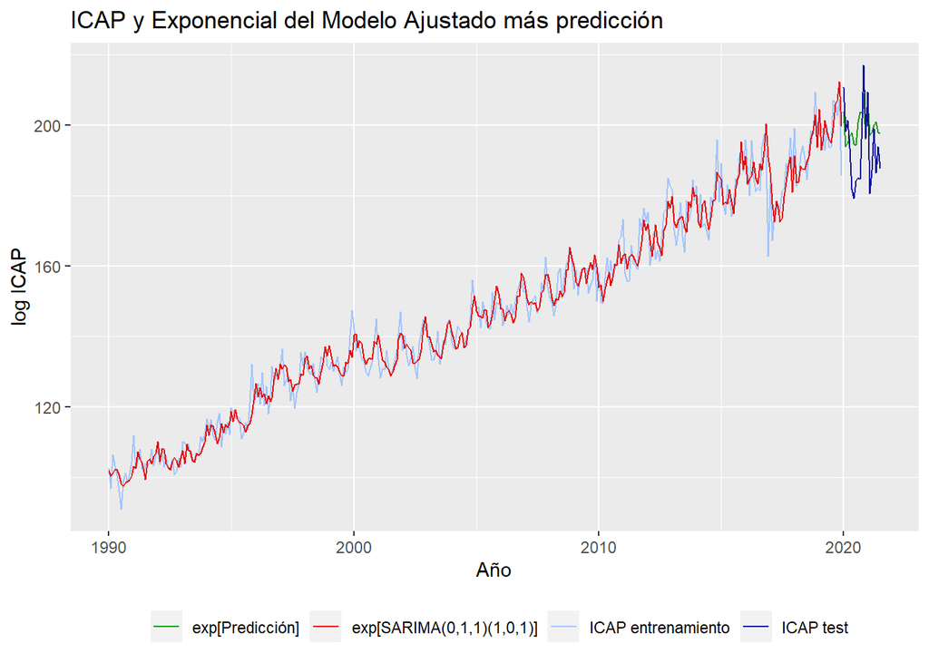

```r
autoplot(serie_ent,series="ICAP entrenamiento")+
  autolayer(exp(sarima1$fitted),series = "exp[SARIMA(0,1,1)(1,0,1)]")+
  autolayer(exp(prediccion$mean),series = "exp[Predicción]")+
  autolayer(serie_test,series = "ICAP test")+
  ggtitle("ICAP y Exponencial del Modelo Ajustado más predicción")+
  xlab("Año")+ylab("log ICAP")+
  scale_color_manual(values=c("#189B0D","#E80808","#A4C4FC","#0D139B"))+
  theme(legend.position = "bottom",legend.title = element_blank() )
```

# 8 MAPE

Se calcula el MAPE para la predicción de los datos del conjunto del test.

```r
mape<-function(y,f){
  pe<-((y-f)/y)
  mape1<-(sum(abs(pe))/length(y))*100
  return(mape1)
}
mape(log(serie_test),prediccion$mean)
```

```
## [1] 0.8683145
```

```r
mape_test<-mape(serie_test,exp(prediccion$mean))
mape_test
```

```
## [1] 4.680337
```

El MAPE es igual a 4.6803368, esto aplicado a la exponencial de las predicciones.

# 9 Comparación de la predicción

El MAPE obtenido por el método de suavizamiento exponencial específicamente al modelo Holt-Winters aplicado a la serie de entrenamiento fue de $4.5956761$ y el MAPE obtenido por el modelo $SARIMA(0,1,1)(1,0,1)_{12}$ de Box y Jenkins es 4.6803368 teniendo una diferencia de $0.084$ a favor del modelo Holt-Winters.

Se podría concluir que la diferencia es mínima en cuanto al MAPE se refiere, por tal motivo se puede decir que ambos modelos son óptimos para poder predecir de manera eficiente y consistente la serie del ICAP de Bolivia.

# 10 Conclusiones

Se estudio la serie temporal del indice de consumo de agua potable en Bolivia desde el periodo de enero de 1990 hasta julio del 2021, teniendo en total 379 observaciones con periodicidad mensual, existiendo un valor atípico en diciembre del 2016. Posteriormente se pudo determinar la existencia de tendencia aditiva con estacionalidad, lo cual derivó a tener no estacionariedad en media y varianza, probando así la Función de Autocorrelación FAC y las dócimas de Dickey Fuller Aumentado.

Se transformó la serie con logaritmo para estabilizar varianza y posteriormente se hizo una diferencia de rezago $1$ que era el único necesario teniendo una serie estacionaria, ya que con rezago $12$ también se cumplia estacionariedad pero solo bastaba con la primera diferencia.

Se ajustó con la metodología de Box y Jenkins a un modelo $SARIMA(0,1,1)(1,0,1)_{12}$ que presentaba estimadores de parámetros significativos y el menor AIC de todos los modelos propuestos, se realizó la validación de supuestos teniendo así independencia y homocedasticidad en los residuos. En cuanto a la normalidad es necesario comentar que no cumple este supuesto al tener el dato atípico de diciembre de 2016, obviando este dato el supuesto de normalidad en los residuos se cumple.

Al pronosticar los datos con el modelo $SARIMA(0,1,1)(1,0,1)_{12}$ y obtener el MAPE del mismo, se comparó con el MAPE del modelo Holt Winters realizado en el anterior trabajo y se obtuvo una diferencia de $0.084$, mostrando así una mínima diferencia entre ambos, lo cual deriva a decir que tanto el modelo de Box y Jenkins y el de suavizamiento exponencial son eficientes para realizar pronósticos a la serie del ICAP de Bolivia.

[^1]: www.ine.gob.bo
[^2]: https://cnnespanol.cnn.com/2016/11/21/declaran-emergencia-nacional-en-bolivia-por-sequia-y-falta-de-agua/